# Optimal portfolios in the high-dimensional setting

## Development of wealth

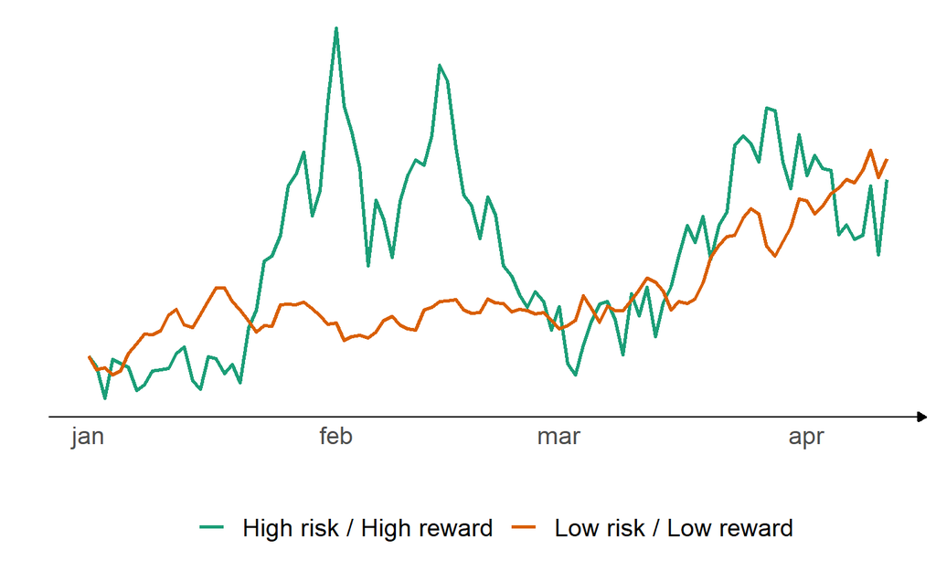

## The ‘’Low risk / Low reward’’ portfolio

Low risk portfolio from Markowitz (1959) is the Global Minimum Variance (GMV) portfolio \[ \min_\mathbf{w}\mathbf{w}^\top \mathbf{\Sigma}\mathbf{w},\\\;\; \text{s.t.} \;\mathbf{w}^\top \mathbf{1}= 1. \] where the solution is \[ \mathbf{w}_{GMV}=\frac{\mathbf{\Sigma}^{-1} \mathbf{1}}{\mathbf{1}^\top \mathbf{\Sigma}^{-1} \mathbf{1}}. \]

## This thesis in a slide - Estimation & diversification

- In practice we do not know \(\mathbf{\Sigma}\), *estimate* with \(\mathbf{S}\) from \(n\) obs. How accurate is that estimate?
- We want \(p\) to be large, e.g, *diversify* a lot.
  - \(\mathbf{S}\) has \(p(p+1)/2\) parameters \(\rightarrow\) curse of dimensionality!
  - We want to use \(\mathbf{S}^{-1}\) for GMV, not \(\mathbf{S}\). How accurate is \(\mathbf{S}^{-1}\) or \[ \widehat{\mathbf{w}}_{GMV} = \frac{\mathbf{S}^{-1} \mathbf{1}}{\mathbf{1}^\top \mathbf{S}^{-1} \mathbf{1}} \] when \(p\) and \(n\) is large?
- Understand difference between using \(\mathbf{\Sigma}\) and \(\mathbf{S}\) and/or construct ‘’better’’ portfolios.

## Summary of papers in this thesis

| Paper | \(n,p\rightarrow \infty ^1\) | \(n,p\)<\(\infty^2\) | Portfolios | Model |
| --- | --- | --- | --- | --- |
| I | \(\cdot\) | \(\cdot\) | Many! | Normal |
| II | \(\cdot\) | \(\cdot\) | TP | Normal with skewness |
| III | \(\cdot\) |  | GMV | Location-scale |
| IV | \(\cdot\) |  | GMV | Location-scale |
| V | \(\cdot\) |  | GMV | Location-scale |

<sup>1</sup> high-dimensional portfolios, a lot of data & assets.  
<sup>2</sup> finite-sample, not that much data and assets.

## Paper I & II

### Together with Taras Bodnar, Nestor Parolya, Holger Dette, Stepan Mazur & Farrukh Javed

## Paper I & II - Sampling distributions & understanding uncertainty

- If we use \(\mathbf{S}\) instead of \(\mathbf{\Sigma}\) we introduce estimation uncertainty.
- Aim is to answer questions such as:
  - Are we certain that we bought the ‘’correct’’ amount of units in asset A?
  - Hope that the portfolio will increase with \(8\%\) each year, how certain are we about it?
- We make specific assumptions, but can get a deeper understanding of what happens!

## Paper I & II - Results

- *Paper I* investigates the sampling distribution of *any* portfolio in the MPT framework.
  - Sample quantities are biased, some not consistent \(n,p\rightarrow \infty\).
  - We construct consistent estimators!
- *Paper II* investigates the sampling portfolio from the expected quadratic utility problem *with a risk-free asset*
  - Same thing as the above, skewness from model makes matters worse.

## Paper III, IV & V

### Together with Taras Bodnar & Nestor Parolya

## Shrinkage in high-dimensional portfolios

- Even though \(\widehat{\mathbf{w}}_{GMV}\) minimize in-sample risk, it will not minimize future risk, \(\widehat{\mathbf{w}}_{GMV}^\top \mathbf{\Sigma}\widehat{\mathbf{w}}_{GMV}\) if \(p/n\approx 1\).
- Shrink the weights to something we know (Bodnar, Parolya, and Schmid (2018)) \[ \widehat{\mathbf{w}} =\psi \widehat{\mathbf{w}}_{GMV} + (1-\psi)\mathbf{b} \] where \(\mathbf{b}\) is “some target portfolio.”
  - Introduces bias to the portfolio but will lower its variance/risk.
  - How do we determine \(\psi\)? Loss: \(\widehat{\mathbf{w}}^\top \mathbf{\Sigma}\widehat{\mathbf{w}}\), cross-validation/consistent estimator \(\psi\).

## Paper IV - Informative risk measures, \(n,p \rightarrow \infty\)

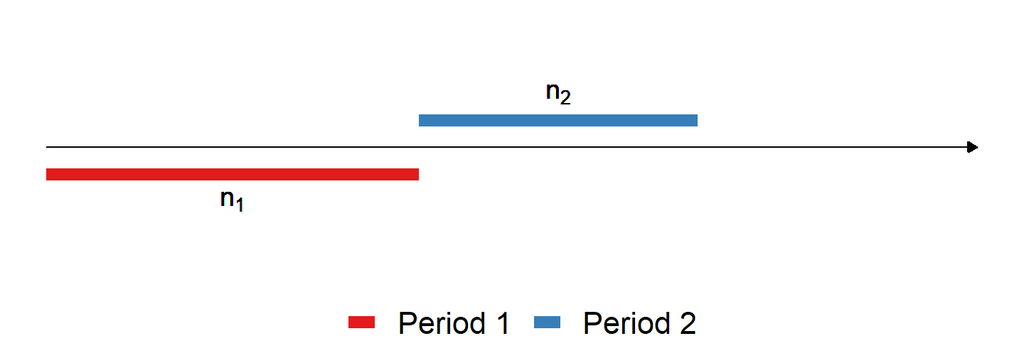

- Compare the empirical out-of-sample variance \(\hat{V}_{n_1, n_2} = \widehat{\mathbf{w}}_{n_1}^\top \mathbf{S}_{n_2} \widehat{\mathbf{w}}_{n_1}\) and the empirical relative loss \[ \hat{L}_{n_1, n_2} = \left(1-\frac{p}{n_2}\right)\hat{V}_{n_1, n_2} \mathbf{1}^\top \mathbf{S}^{-1}_{n_1} \mathbf{1}-1 \]
- Comparison of three different strategies to estimate \(\psi\): Frahm and Memmel (2010), Bodnar, Parolya, and Schmid (2018) & sample GMV

## Paper IV - Results

- \(\hat{V}_{n_1, n_2}\) is informative, though bad for some \(\mathbf{\Sigma}\).
- Dominance results/Ordering in loss and variance of the three different portfolios \(n,p \rightarrow \infty\).
- Empirically ordering holds \(n,p < \infty\)

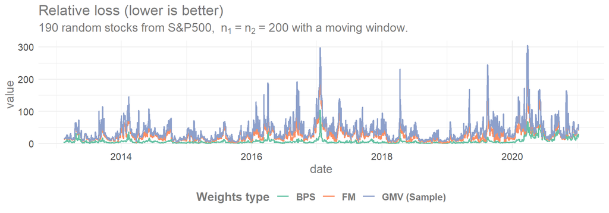

## Paper III - Dynamic Shrinkage estimation

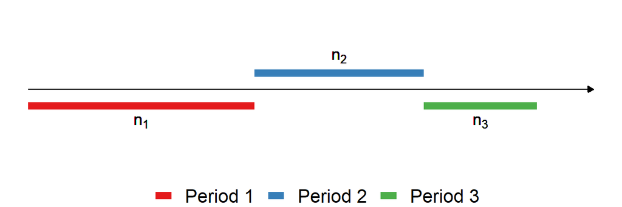

- We work with \(\widehat{\mathbf{w}}_{n_i}=\psi_{n_i} \widehat{\mathbf{w}}_{GMV;n_i} + (1-\psi_{n_i})\widehat{\mathbf{w}}_{n_{i-1}}\) (extension of Bodnar, Parolya, and Schmid (2018))
- Estimate \(\psi_{n_i}\) at each transition, optimal when \(n,p \rightarrow \infty\)
- Datasets can be overlapping, so Period 2 can contain data from Period 1!

## Paper III - Results

- We compare a number of different strategies, most notably Ledoit and Wolf (2020) nonlinear covariance estimator.
- Simulations show that the method is robust and often provides the smallest relative loss.
- Empirically, Ledoit and Wolf (2020) is better at taking ‘’low-risk’’ positions, our method provides better out-of-sample variance, mean, turnover.
- Methods are in the `DOSPortfolio` package (on CRAN!).

## Paper V - Double shrinkage

- An extension to the linear shrinkage, includes ridge type regularization to \(\mathbf{S}\) \[ \widehat{\mathbf{w}} = \psi \frac{(\mathbf{S}+ \eta \mathbf{I})^{-1}\mathbf{1}}{\mathbf{1}^\top(\mathbf{S}+ \eta \mathbf{I})^{-1}\mathbf{1}} + (1-\psi) \mathbf{b} \]
- \(p>n\), previously \(p<n\).
- Can not determine \(\eta, \psi\) analytically \(\rightarrow\) estimator of \(\widehat{\mathbf{w}}^\top \mathbf{\Sigma}\widehat{\mathbf{w}}\), consistent when \(n,p \rightarrow \infty\).

## Paper V - Results

- We compare to a number of different strategies, Ledoit and Wolf (2020), Bodnar, Parolya, and Schmid (2018), Frahm and Memmel (2010) for different \(\mathbf{b}\)
- Simulations show that Double is also robust and on par with the Ledoit and Wolf (2020).
- Empirically, Double performs well, example \(p=431, n=250\)

  Variance and Turnover, lower is better. Mean, higher is better.

  |  | BPS ec | BPS ew | Double ec | Double ew | ew | LW2020 | GMV (sample) |
  | --- | --- | --- | --- | --- | --- | --- | --- |
  | Variance | \(0.0121\) | \(0.01217\) | \(\mathbf{0.01088}\) | \(0.01117\) | \(0.01116\) | \(\mathit{0.01105}\)* | \(0.01322\) |
  | Mean | \(0.000437\) | \(0.00042\) | \(0.000496\) | \(\mathbf{0.000516}\) | \(0.000512\) | \(\mathit{0.000515}\)* | \(0.000375\) |
  | Turnover | \(3165.55\) | \(3192.65\) | \(\mathit{69.99}\)* | \(\mathbf{5.19}\) |  | \(660.56\) | \(4254.45\) |

- *Double is consistently the best in terms of low-risk positions!*

## Summary

This thesis provides several ways to better understand the investment process and/or to construct ‘’good’’ portfolios when \(n,p\rightarrow \infty\). We either

- make stronger assumptions to get a deeper understanding of the quantities of interest.
- make very general assumptions, construct ‘’good’’ portfolios but we might provide less intuition.

All code for this thesis is available on [my github page (https://github.com/Ethorsn)](https://github.com/Ethorsn/Phd-thesis)

## References

Bodnar, Taras, Nestor Parolya, and Wolfgang Schmid. 2018. “Estimation of the Global Minimum Variance Portfolio in High Dimensions.” *European Journal of Operational Research* 266 (1): 371–90.

Frahm, Gabriel, and Christoph Memmel. 2010. “Dominating Estimators for Minimum-Variance Portfolios.” *Journal of Econometrics* 159 (2): 289–302.

Ledoit, Olivier, and Michael Wolf. 2020. “ Analytical Nonlinear Shrinkage of Large-dimensional Covariance Matrices.” *The Annals of Statistics* 48 (5): 3043–65.

Markowitz, Harry. 1959. *Portfolio Selection: Efficient Diversification of Investments*. John Wiley & Sons, Inc; Chapman & Hall, Ltd.